# Vibe coding example 問いかけと出力記録

Author

Seiro Ito

Published

October 07, 2026, 07:10 +0900

# Meta prompt

Below is what I asked you in the terminal.

> I am a student who is analyzing data related to development and health. Find ViveCodingExample.qmd in this folder. Read the Procedure. Respond to my Instructions and render the file. I will update the file each time I receive your outputs written in the file.

# Procedure

- I will add “Instructions” as you provide “Outputs.”
- You will add outputs right after each instruction. Also add “X+1th query” subsection, “Instructions”, and “Outputs” when you respond to the X-th query.
- When you provide codes, they must be either in R or Python. R is the most preferred language. Use Python only if you cannot get the task done with R.
- Code blocks must not result in a horizontal scroll bar. Use linebreaks.
- Use a Tufte style css.
- Outputs must be succinct. Do not provide any analytical comments. I will do the interpretations. Provide only data related information that is useful in interpreting outputs, and the reason of your choices in creating outputs.
- Output html should be VibeCodingExampleX.html for X-th turn. Use double digits for X like 01, 02, …

# Instructions and outputs

## 1st query

### Instructions

- I am trying to find empirical relationship between child mortality and per capita health spending across countries.
- Final output is a scatter plot with a line connecting each points, showing time series changes by country in a single figure.
- X axis is spendings, Y axis is mortality, and points are connected by a line for a same country. Use colour blind aware colour schemes, as in viridis.
- Find most suitable variables from WB data, WHO, DHS.

### outputs

Variables (all from World Bank WDI, fetched with the R package `WDI`)

| Axis | Variable | WDI code | Unit | Original source |
| --- | --- | --- | --- | --- |
| Y | Under-5 mortality rate | SH.DYN.MORT | deaths per 1,000 live births | UN IGME (WHO/UNICEF/WB/UN) |
| X | Current health expenditure per capita | SH.XPD.CHEX.PP.CD | current int'l $, PPP | WHO Global Health Expenditure Database |

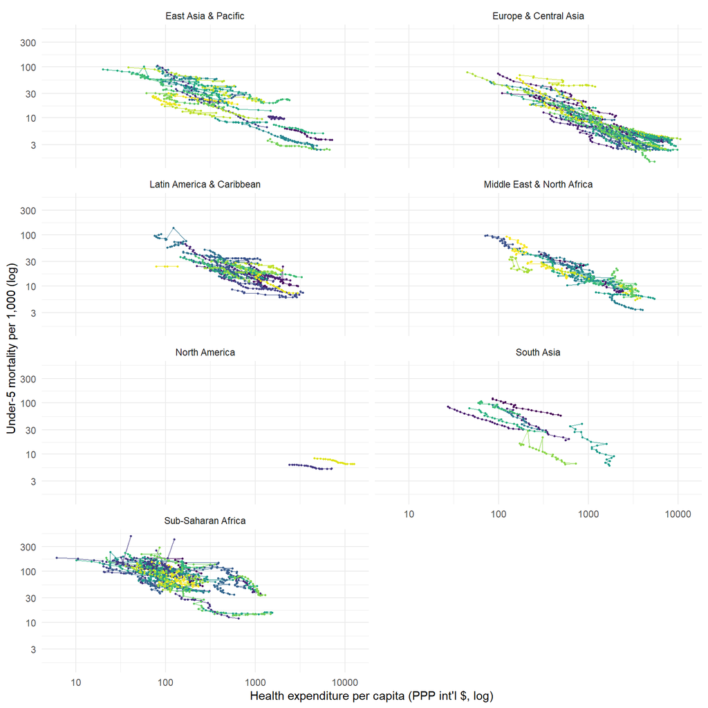

```r
library(WDI)
library(dplyr)
library(ggplot2)
# WB API is slow: longer download timeout
old <- getOption("timeout")
options(timeout = 300)
d <- WDI(
  indicator = c(u5m  = "SH.DYN.MORT",
                hexp = "SH.XPD.CHEX.PP.CD"),
  start = 2000, end = 2022, extra = TRUE
) |>
  filter(region != "Aggregates",
         !is.na(region)) |>
  select(iso3c, country, region, year,
         u5m, hexp)
options(timeout = old)  # restore
dp <- d |>
  filter(!is.na(u5m), !is.na(hexp)) |>
  arrange(iso3c, year)
ggplot(dp, aes(hexp, u5m,
               colour = country,
               group = country)) +
  geom_path(alpha = .6) +
  geom_point(size = .6) +
  scale_x_log10() +
  scale_y_log10() +
  scale_colour_viridis_d() +
  facet_wrap(~ region, ncol = 2) +
  labs(x = paste("Health expenditure per",
                 "capita (PPP int'l $, log)"),
       y = paste("Under-5 mortality per",
                 "1,000 (log)")) +
  theme_minimal() +
  theme(legend.position = "none")
```

Data notes

```r
tibble(
  item = c("countries fetched",
           "countries plotted",
           "country-years plotted",
           "years",
           "missing u5m",
           "missing hexp"),
  value = c(n_distinct(d$iso3c),
            n_distinct(dp$iso3c),
            nrow(dp),
            paste(range(dp$year),
                  collapse = "-"),
            sum(is.na(d$u5m)),
            sum(is.na(d$hexp)))
) |> tt_st()  # was knitr::kable()
```

| item | value |
| --- | --- |
| countries fetched | 214 |
| countries plotted | 190 |
| country-years plotted | 4304 |
| years | 2000-2022 |
| missing u5m | 460 |
| missing hexp | 608 |

## 2nd query

### Instructions

Aesthetic

- Expand the main text width. Way too narrow. The variable table width can be the main text width.
- Horizontal scroll bars are present. Use linebreaks in codeblocs so they will go away.
- For tables, use tinytable package. Use striped theme, but headers need to be in faintly light blue. Headers and 1st column (data name) must be centre aligned, all other descriptive columns should be right aligned.

Contents

- Your reasoning of using WHO is not acceptable. I do not mind making as many calls as possible, or merging two data sets using country names or ISO3. The reason should be based on the superiority of data contents in achieving the goal of this task.

  > WDI rather than WHO GHO API: both variables in one call, same country codes and region labels.
- Give me a list of data sources and their strengths and weaknesses in a concise table.
- In comparing contents of different data, we need to facet figures side by side. facet_grid(~ data).

### Outputs

Aesthetic changes (whole document)

- Text width: the Tufte CSS caps paragraphs and tables at 55% and code at 52.5% of the column; a CSS chunk at the top sets them to 100%, and the body width is 900px.
- Code: lines at most 55 characters.
- Tables: `tinytable`, striped theme, header background `#e8f1fb`, header and 1st column centred, other columns right-aligned (function `tt_st()`, code below). The two 1st-query tables now use it.

```r
library(tinytable)
# dplyr here too: a cache hit on u5m-hexp
# does not attach it for later chunks
library(dplyr)
# striped, light-blue header, header and
# 1st column centred, others right-aligned
tt_st <- function(d) {
  # width: CSS chunk sets 100%, auto layout
  x <- tt(d)
  x <- theme_striped(x)
  x <- style_tt(x, i = 0, align = "c",
                background = "#e8f1fb")
  x <- style_tt(x, j = 1, align = "c")
  if (ncol(d) > 1) {
    x <- style_tt(x, i = seq_len(nrow(d)),
                  j = 2:ncol(d), align = "r")
  }
  x
}
```

Data download (latest releases at render time; WHO GHED is a 39 MB xlsx)

```r
library(WDI)
library(jsonlite)
library(readr)
library(readxl)
old <- getOption("timeout")
options(timeout = 600)
# WDI: u5m, current-PPP spending, regions
wdi <- WDI(
  indicator = c(u5m  = "SH.DYN.MORT",
                hexp = "SH.XPD.CHEX.PP.CD"),
  start = 1960, end = 2025, extra = TRUE)
wdi <- wdi[wdi$region != "Aggregates" &
             !is.na(wdi$region), ]
reg <- unique(wdi[, c("iso3c", "region")])
# UN IGME (UNICEF SDMX API): u5m + bounds
igme_url <- paste0(
  "https://sdmx.data.unicef.org/ws/public/",
  "sdmxapi/rest/data/UNICEF,CME,1.0/",
  ".CME_MRY0T4._T?format=csv")
igme <- read_csv(igme_url,
                 show_col_types = FALSE)
igme <- igme[igme$WEALTH_QUINTILE == "_T" &
               grepl("^[A-Z]{3}$",
                     igme$REF_AREA), ]
igme <- data.frame(
  iso3c = igme$REF_AREA,
  year  = as.integer(
    substr(igme$TIME_PERIOD, 1, 4)),
  u5m   = igme$OBS_VALUE,
  lo    = igme$LOWER_BOUND,
  hi    = igme$UPPER_BOUND)
# WHO GHO API: u5m, both sexes
gho_url <- paste0(
  "https://ghoapi.azureedge.net/api/",
  "MDG_0000000007")
gho <- fromJSON(gho_url)$value
gho <- gho[gho$SpatialDimType == "COUNTRY" &
             gho$Dim1 == "SEX_BTSX", ]
gho_t <- gho[gho$Dim3 ==
               "WEALTHQUINTILE_TOTL", ]
# DHS API: direct estimate, 5 years
# preceding the survey
dhs_url <- paste0(
  "https://api.dhsprogram.com/rest/dhs/",
  "data?indicatorIds=CM_ECMR_C_U5M",
  "&perpage=5000&f=json")
dhs <- fromJSON(dhs_url)$Data
dhs <- dhs[dhs$IsTotal == 1 &
             dhs$IsPreferred == 1, ]
dcn <- fromJSON(paste0(
  "https://api.dhsprogram.com/rest/dhs/",
  "countries?f=json"))$Data
dhs$iso3c <- dcn$ISO3_CountryCode[
  match(dhs$DHS_CountryCode,
        dcn$DHS_CountryCode)]
# WHO GHED: full database
ghed_f <- tempfile(fileext = ".xlsx")
download.file(paste0(
  "https://apps.who.int/nha/database/",
  "Home/IndicatorsDownload/en"),
  ghed_f, mode = "wb", quiet = TRUE)
ghed_ver <- read_excel(
  ghed_f, sheet = "Version")[[1]][2]
ghed <- read_excel(ghed_f, sheet = "Data")
ghed <- ghed[, c("code", "year",
                 "che_ppp_pc", "che_ncu2023",
                 "ppp", "pop")]
options(timeout = old)  # restore
# constant 2023 int'l $ per capita =
# million const. 2023 NCU / 2023 PPP / pop
p23 <- ghed[ghed$year == 2023, ]
ghed$ppp23 <- p23$ppp[match(ghed$code,
                            p23$code)]
ghed$hexp_k <- ghed$che_ncu2023 * 1e6 /
  ghed$ppp23 / (ghed$pop * 1e3)
```

Agreement between sources (same country-year)

```r
m1 <- merge(igme,
  data.frame(iso3c = gho_t$SpatialDim,
             year = gho_t$TimeDim,
             g = gho_t$NumericValue))
m2 <- merge(wdi[, c("iso3c", "year", "u5m")],
  igme[, c("iso3c", "year", "u5m")],
  by = c("iso3c", "year"))
m3 <- merge(wdi[, c("iso3c", "year", "hexp")],
  data.frame(iso3c = ghed$code,
             year = ghed$year,
             h = ghed$che_ppp_pc))
r3 <- abs(m3$hexp / m3$h - 1)
tt_st(data.frame(
  Comparison = c("u5m: GHO vs UN IGME",
                 "u5m: WDI vs UN IGME",
                 "spending: WDI vs GHED"),
  `Country-years` = c(nrow(m1), nrow(m2),
                      sum(!is.na(r3))),
  `Max relative difference` = sprintf(
    "%.4f", c(max(abs(m1$u5m / m1$g - 1)),
              max(abs(m2$u5m.x /
                        m2$u5m.y - 1)),
              max(r3, na.rm = TRUE))),
  `Share differing > 1%` = sprintf(
    "%.3f", c(mean(abs(m1$u5m / m1$g - 1)
                   > .01),
              mean(abs(m2$u5m.x /
                         m2$u5m.y - 1) > .01),
              mean(r3 > .01, na.rm = TRUE))),
  check.names = FALSE))
```

| Comparison | Country-years | Max relative difference | Share differing > 1% |
| --- | --- | --- | --- |
| u5m: GHO vs UN IGME | 13295 | 0.0000 | 0.000 |
| u5m: WDI vs UN IGME | 11778 | 0.0321 | 0.015 |
| spending: WDI vs GHED | 4526 | 0.9967 | 0.002 |

Data sources

```r
nc <- function(iso, v) {
  length(unique(iso[!is.na(v)]))
}
yr <- function(y, v) {
  paste(range(y[!is.na(v)]), collapse = "-")
}
tt_st(data.frame(
  Data = c("WDI", "UN IGME", "WHO GHO",
           "DHS", "WHO GHED"),
  Years = c(yr(wdi$year, wdi$u5m),
            yr(igme$year, igme$u5m),
            yr(gho_t$TimeDim,
               gho_t$NumericValue),
            yr(dhs$SurveyYear, dhs$Value),
            yr(ghed$year, ghed$che_ppp_pc)),
  Countries = c(nc(wdi$iso3c, wdi$u5m),
                nc(igme$iso3c, igme$u5m),
                nc(gho_t$SpatialDim,
                   gho_t$NumericValue),
                nc(dhs$iso3c, dhs$Value),
                nc(ghed$code, ghed$che_ppp_pc)),
  Strengths = c(
    "WB region and income-group labels",
    paste("latest u5m round; lower/upper",
          "bounds; wealth quintiles"),
    paste("u5m equals UN IGME;",
          "wealth quintiles"),
    paste("direct survey estimate, not",
          "modelled; confidence interval"),
    paste("source of all spending series;",
          "constant prices; gov./private/",
          "external split")),
  Weaknesses = c(
    paste("older UN IGME round; spending in",
          "current PPP only"),
    "no spending; modelled where data sparse",
    "PPP spending series return no rows",
    paste("refers to 5 years before survey;",
          "few surveys per country"),
    "starts 2000; latest year preliminary"),
  check.names = FALSE))
```

| Data | Years | Countries | Strengths | Weaknesses |
| --- | --- | --- | --- | --- |
| WDI | 1960-2024 | 194 | WB region and income-group labels | older UN IGME round; spending in current PPP only |
| UN IGME | 1931-2024 | 200 | latest u5m round; lower/upper bounds; wealth quintiles | no spending; modelled where data sparse |
| WHO GHO | 1931-2024 | 200 | u5m equals UN IGME; wealth quintiles | PPP spending series return no rows |
| DHS | 1985-2025 | 87 | direct survey estimate, not modelled; confidence interval | refers to 5 years before survey; few surveys per country |
| WHO GHED | 2000-2024 | 195 | source of all spending series; constant prices; gov./private/ external split | starts 2000; latest year preliminary |

- GHED version: Last updated: December 12th, 2025.
- “Countries” counts areas with at least one value of u5m (spending for GHED).

Choices and reasons (content of the data)

- Y, main: UN IGME. Its u5m is the newest estimation round and carries lower/upper bounds; WDI republishes an older round, and WHO GHO publishes identical numbers (table above).
- X, main: WHO GHED, constant 2023 int’l $ per capita (`che_ncu2023` / 2023 PPP / population). A movement along a country’s line is then a real change, not price inflation in current int’l $. WDI carries only the current-PPP copy of the GHED series.
- WHO GHO not plotted: its u5m equals UN IGME and its PPP spending indicators are empty.
- DHS panel: an independent, survey-based u5m. Spending is the mean of GHED constant 2023 $ over the survey year and the 4 years before it (the 5-year window of the estimate); surveys with fewer than 3 GHED years are dropped.
- Colours: Okabe–Ito palette (colour-blind safe) for 7 WB regions; viridis gave two near-identical dark colours at 7 categories.

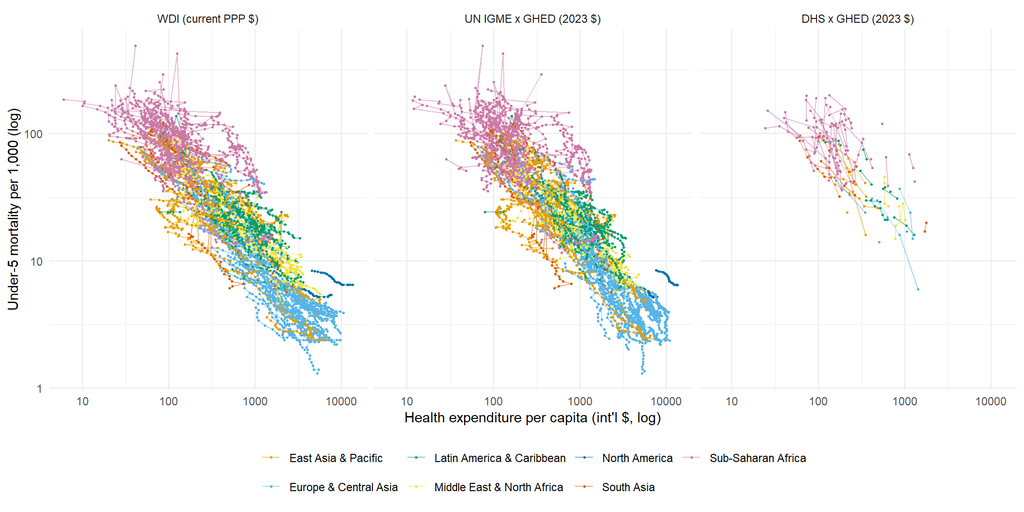

```r
library(ggplot2)
p1 <- data.frame(
  data = "WDI (current PPP $)",
  iso3c = wdi$iso3c, year = wdi$year,
  u5m = wdi$u5m, hexp = wdi$hexp)
p2 <- merge(igme[, c("iso3c", "year", "u5m")],
            data.frame(iso3c = ghed$code,
                       year = ghed$year,
                       hexp = ghed$hexp_k))
p2$data <- "UN IGME x GHED (2023 $)"
k <- data.frame(iso3c = ghed$code,
                year = ghed$year,
                h = ghed$hexp_k)
dhs$hexp <- NA_real_
dhs$nyr <- 0L
for (r in seq_len(nrow(dhs))) {
  s <- k$h[k$iso3c == dhs$iso3c[r] &
             k$year >= dhs$SurveyYear[r] - 4 &
             k$year <= dhs$SurveyYear[r]]
  s <- s[!is.na(s)]
  dhs$nyr[r] <- length(s)
  if (length(s) >= 3) dhs$hexp[r] <- mean(s)
}
p3 <- data.frame(
  data = "DHS x GHED (2023 $)",
  iso3c = dhs$iso3c, year = dhs$SurveyYear,
  u5m = dhs$Value, hexp = dhs$hexp)
cols <- c("data", "iso3c", "year",
          "u5m", "hexp")
pd <- rbind(p1[, cols], p2[, cols],
            p3[, cols])
pd <- pd[!is.na(pd$u5m) &
           !is.na(pd$hexp) & pd$hexp > 0, ]
pd$region <- reg$region[match(pd$iso3c,
                              reg$iso3c)]
pd <- pd[!is.na(pd$region), ]
pd$data <- factor(pd$data,
                  levels = unique(pd$data))
pd <- pd[order(pd$data, pd$iso3c,
               pd$year), ]
oi <- unname(palette.colors(
  8, "Okabe-Ito"))[2:8]
ggplot(pd, aes(hexp, u5m,
               colour = region,
               group = iso3c)) +
  geom_path(alpha = .5) +
  geom_point(size = .5) +
  scale_x_log10() +
  scale_y_log10() +
  scale_colour_manual(values = oi) +
  facet_grid(~ data) +
  labs(x = paste("Health expenditure per",
                 "capita (int'l $, log)"),
       y = paste("Under-5 mortality per",
                 "1,000 (log)"),
       colour = NULL) +
  theme_minimal() +
  theme(legend.position = "bottom")
```

Data notes

```r
tt_st(data.frame(
  Panel = levels(pd$data),
  Countries = as.vector(tapply(
    pd$iso3c, pd$data,
    function(x) length(unique(x)))),
  `Country-years` = as.vector(
    table(pd$data)),
  Years = as.vector(tapply(
    pd$year, pd$data,
    function(x) paste(range(x),
                      collapse = "-"))),
  check.names = FALSE))
```

| Panel | Countries | Country-years | Years |
| --- | --- | --- | --- |
| WDI (current PPP $) | 190 | 4515 | 2000-2024 |
| UN IGME x GHED (2023 $) | 190 | 4516 | 2000-2024 |
| DHS x GHED (2023 $) | 71 | 203 | 2002-2025 |

- DHS surveys dropped for fewer than 3 GHED years: 126 of 329.

## 3rd query